# Lecture 9 - Re-thinking neurodiversity

# Systems (not syndromes)

## Nosology

- The branch of medical science dealing with the classification of diseases.

[figure not shown]

[figure not shown]

## Systems (not syndromes)

[figure not shown]

(Fried, 2022)

## Natural kinds

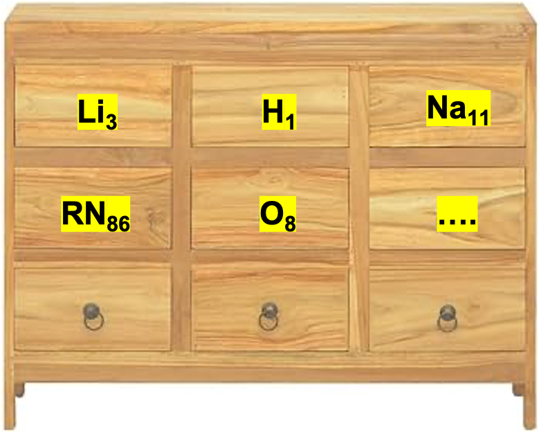

(Fried, 2022)

## Natural kinds of disease unit?

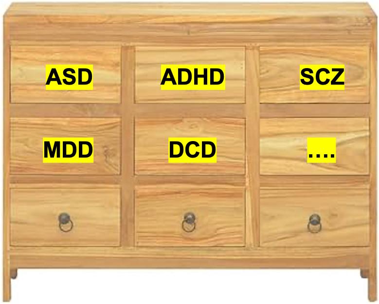

(Fried, 2022)

## Historical forces, not empirical evidence

- E.g., depression DSM-5 criteria:
- 1 of the first 2 symptoms
- at least 5/9 symptoms
- for at least 14 days

How were these thresholds determined?

(Fried, 2022)

## Diagnostic literalism

- We take diagnostic categories for more than they are, which impedes progress.

e.g., case-control studies for depression, for example, assume that depression is a neat category. Two groups: depressed vs. otherwise healthy (or at least, not depressed).

- “what are genes for depression?”
- “what are the risk factors for depression?”

(Fried, 2022)

## Evidence does not support neat categories

- Inter-rater reliability
- Disagreement about construct definitons
- Heterogeneity
- Comorbidity of diagnostic categories
- Transdiagnostic risk factors
- Dimensions, not catgeories

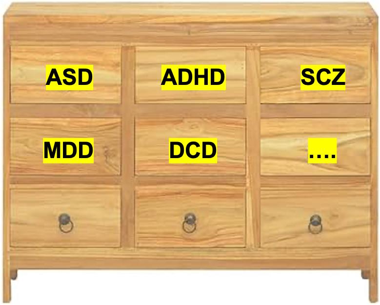

(Fried, 2022)

## Why have categories at all?

- They can be of clinical use
- Semantic efficiency
- Public health and organisation of treatment…

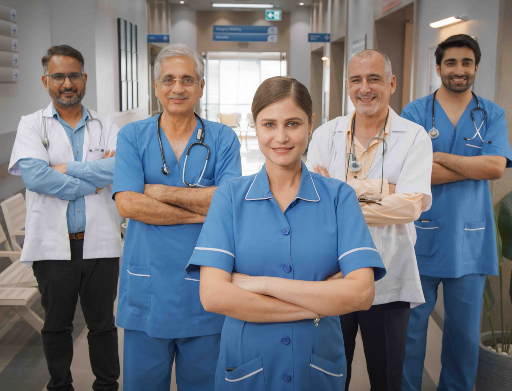

(Fried, 2022)

## Reductionism

- Reduce things into their parts to understand the whole
- This is very useful and helpful in many different settings e.g., a car engine.
- But for complex systems, such as the stock market or weather patterns, reductionism doesn’t work as well.

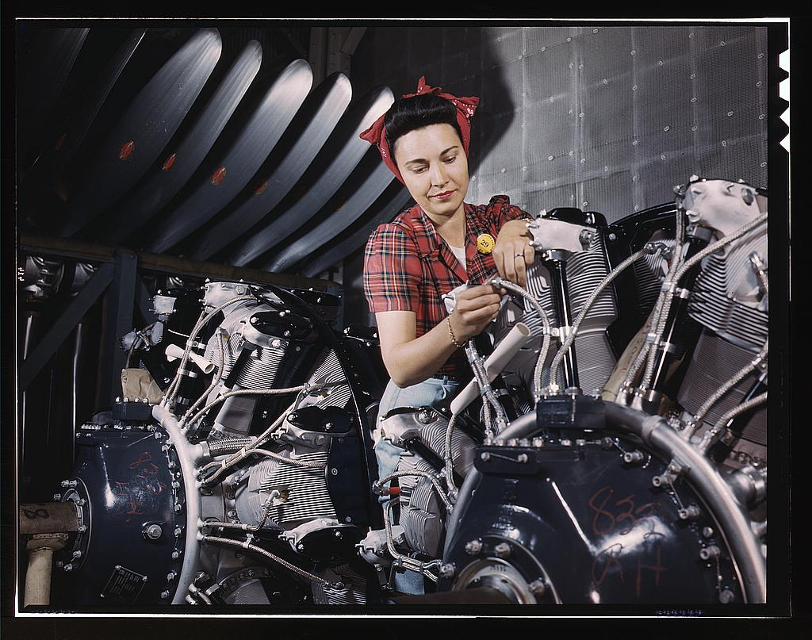

(Fried, 2022)

## Reductionism in mental health

- Study depression using a DSM-5 category (which has limited validity) and only study that one category
- And focus on one level of description (i.e., a biological level)
- Primarily study one-to-one relations

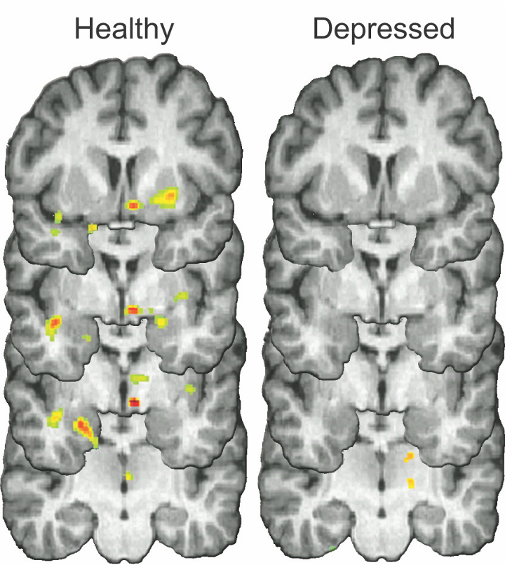

(Fried, 2022)

# Complex systems

## A complex systems perspective

[video not shown]

## A complex systems perspective

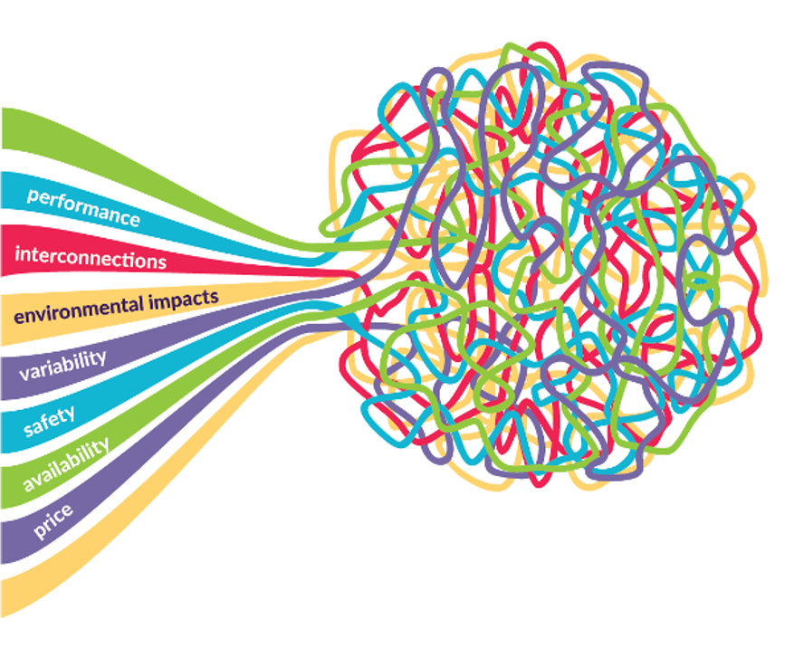

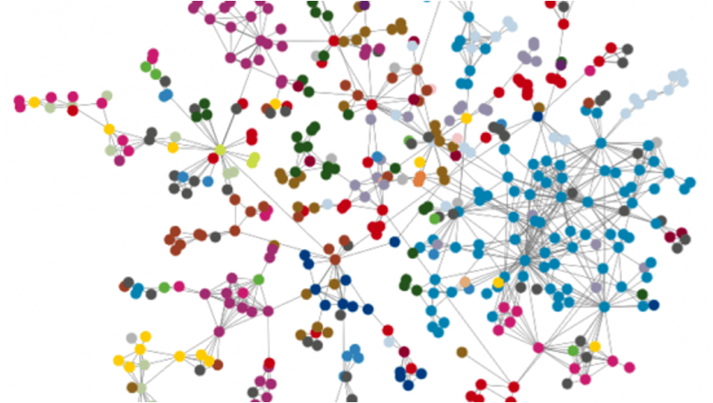

## A complex systems perspective

Lake conditions

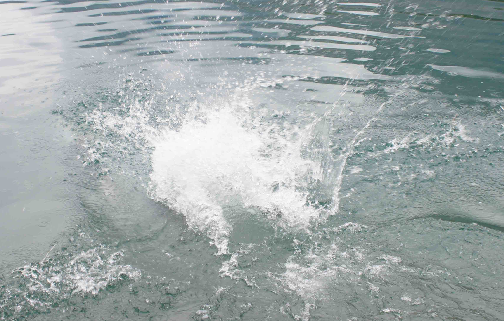

oxygen, sunlight, fish, pollution, etc.

Mood

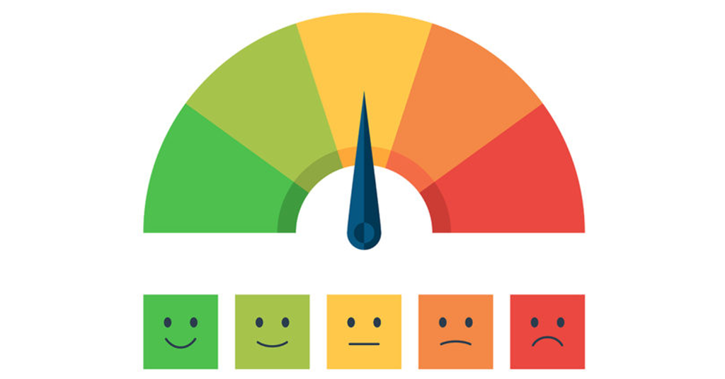

personality, caffeine, sleep, email, etc.

## Mental disorders as complex systems

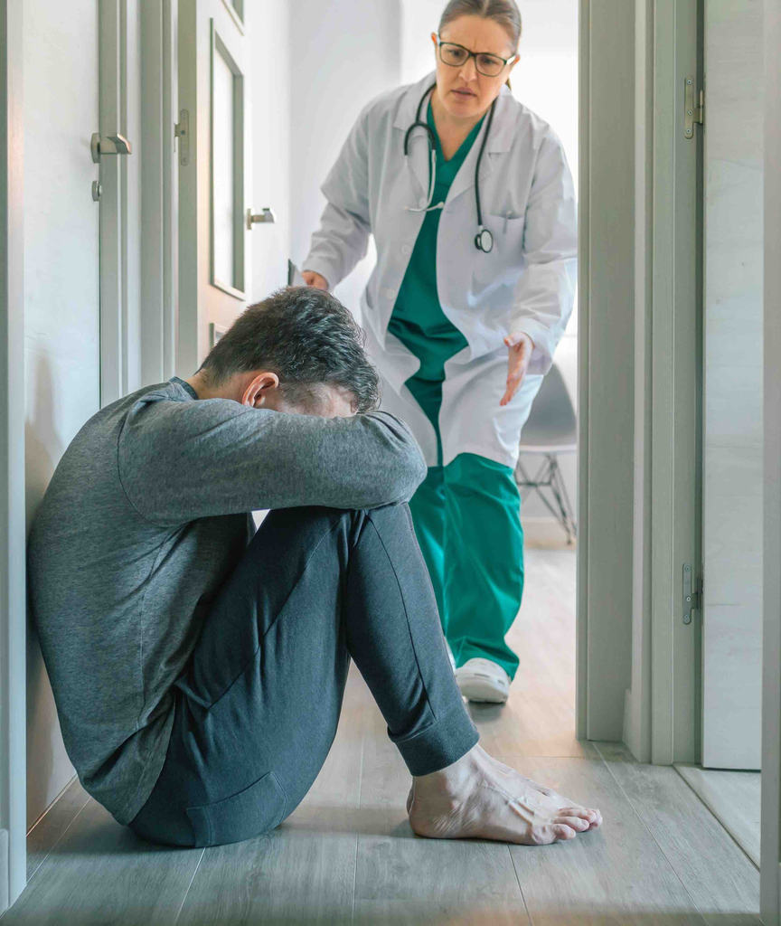

Interactions between:

- biological, psychological, and social features…

e.g., risk and protective factors, moods, thoughts, behaviours, predispositions, social environments.

- One-to-many or many-to-many relations

## Emergence

[video not shown]

# Dimensional frameworks

## Existing dimensional frameworks

- RDoC (NIMH, USA) e.g., Insel et al., 2010, The American Journal of Psychiatry
- HiTOP initiative (Worldwide consortium) e.g., Conway et al., 2019, Perspectives on Psychological Science

(Conway et al., 2019; Insel et al., 2010)

## HiTOP

[figure not shown]

(Conway et al., 2019)

## Dimensions (not categories)

- Rather than mental health categories, we have something else…

> Grounded in decades of research, an alternate framework has emerged that characterizes psychopathology using empirically derived dimensions that cut across the boundaries of traditional diagnoses.
- Primary focus on evidence-based dimensions
- Dimensions evolve over time (i.e., dimensions can change if sufficient evidence is gathered)

(Conway et al., 2019)

## HiTOP Figure 1

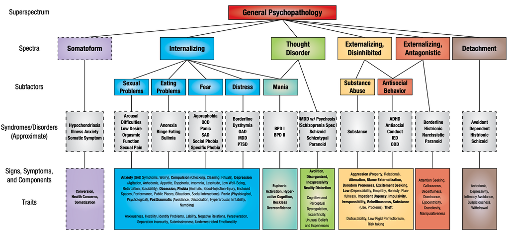

(Conway et al., 2019)

## HiTOP Figure 2

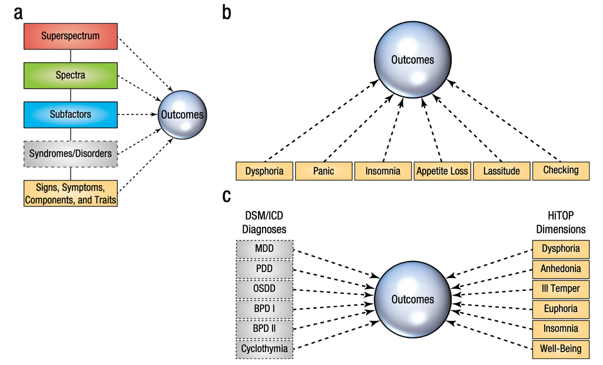

(Conway et al., 2019)

## HiTOP Figure 3

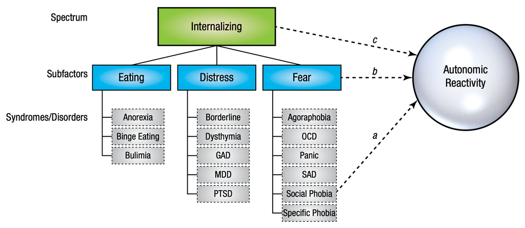

(Conway et al., 2019)

## HiTOP summary

Adopting a hierarchical and dimensional approach, makes it possible to:

- Dissect brain structure and function quantitatviely and thus highlight features that ….
  - are common to many (or all) mental disorders
  - are specific to spectra or syndromes
  - underlie key transdiagnostic symptoms

(Conway et al., 2019)

# Take a break

# Part 2 - Read and discuss

## Discussion material

- break into small groups (~ 5 per group)
- discuss aspects of the lecture
- discuss aspects of the journal article: https://journals.sagepub.com/doi/10.1177/09637214221114089

## References

Conway, C. C., Forbes, M. K., Forbush, K. T., Fried, E. I., Hallquist, M. N., Kotov, R., Mullins-Sweatt, S. N., Shackman, A. J., Skodol, A. E., South, S. C., Sunderland, M., Waszczuk, M. A., Zald, D. H., Afzali, M. H., Bornovalova, M. A., Carragher, N., Docherty, A. R., Jonas, K. G., Krueger, R. F., … Eaton, N. R. (2019). A Hierarchical Taxonomy of Psychopathology Can Transform Mental Health Research. *Perspectives on Psychological Science*, *14*(3), 419–436. https://doi.org/10.1177/1745691618810696

Fried, E. I. (2022). Studying Mental Health Problems as Systems, Not Syndromes. *Current Directions in Psychological Science*, 09637214221114089. https://doi.org/10.1177/09637214221114089

Insel, T., Cuthbert, B., Garvey, M., Heinssen, R., Pine, D. S., Quinn, K., Sanislow, C., & Wang, P. (2010). Research Domain Criteria (RDoC): Toward a New Classification Framework for Research on Mental Disorders. *American Journal of Psychiatry*, *167*(7), 748–751. https://doi.org/10.1176/appi.ajp.2010.09091379

## Acknowledgements

- Unless otherwise specified, icons and images were used under license from [The Noun Project](https://thenounproject.com/)
- Slides were created with [Quarto](https://quarto.org/) and [RevealJS](https://revealjs.com/)